# Group 6 Final Project: Burlington Rental Properties

Anika Miner

Chris McCabe

Luke Fredrickson

5/4/2021

# I. Introduction

In January 2020, Mayor Miro Weinberger enacted an executive order establishing the [Open Data Policy](https://www.burlingtonvt.gov/it/open-data), which enabled access to a large amount of Burlington municipal data. Part of our data comes from [Burlington’s Open Data Portal](https://data.burlingtonvt.gov/pages/home/), in the [Rental Property Certificates of Compliance data set](https://data.burlingtonvt.gov/explore/dataset/rental-property-certificate-of-compliance/information/), which contains data on code compliance for every rental property in Burlington, but no information on which landlord owns that property. The other part of our data is scraped from the [Burlington Property Database](https://property.burlingtonvt.gov/). The Property Database is not downloadable, but it is easy to scrape with a simple python script, and contains more granular detail on property values and landlords. Our final data set combines both of these data sets to provide a rich view of Burlington rental property data. Both data sets are continuously updated, but our final data set is built from data accessed on March 26th, 2021. The final data set can be downloaded [here](https://github.com/lukefredrickson/STAT187-Final-Project/blob/master/properties.csv).

The final properties data set contains the following information:

- **TaxParcelId** (Factor) - A unique identifier for each parcel of land in Burlington, used for tax purposes.
- **SPAN.Number** (Factor) - SPAN stands for “School Property Account Number”. SPAN numbers are a unique 11-digit ID assigned by a municipality in VT to each property.
- **PropertyValue** (Numeric) - The total value of an individual property.
- **PropertyTaxes** (Numeric) - The property taxes for an individual property from the 2020 tax year.
- **Owner** (Factor) - The owner/landlord.
- **CoCYears** (Integer) - The duration of the Certificate of Compliance (CoC) issued for the property. CoCs are issued by the city to each property for durations of 1, 2, 3, 4, or 5 years. If a property has poor code compliance, it will receive a certificate which is valid for fewer years, and if a property complies with code consistently it will receive a 5-year CoC.
- **CoCIssueDate** (Factor) - The date which the CoC was issued for the property.
- **CoCExpireDate** (Factor) - The date which the CoC expires for the property.
- **StreetAddress** (Factor) - The address of the property.
- **LandUseCode** (Factor) - A code assigned to each parcel of land describing what it is used for.
- **ResidentialUnits** (Integer) - The number of units per property.
- **RentalUnits** (Integer) - The number of units for rent per property.
- **AmandaPropertyRSN** (Integer) - Actually Unique identifier for each property.
- **LastMhInspectionDate** (Factor) - The date of the most recent property inspection.
- **lat** (Numeric) - The latitude of the property.
- **long** (Numeric) - The longitude of the property.

The data is comprehensive across the entire city of Burlington, and contains data for every single rental property within the city limits. Because the data set is comprehensive, and not sampled, there is no sampling bias. The data is observational, as it surveys all properties across Burlington, and is collected for city record-keeping purposes. Measurements were collected from official city documents, including tax records and official city inspection data. No questions were asked. It is possible there is some bias in the assessment of property condition or value due to racial discrimination or other factors, but we don’t believe that bias would cause enough variance to be obstructive to our analysis. All other measurements are objective (landlord name, address, coordinates, certificate issue date, etc).

On its own, the Rental Property Certificates of Compliance data set isn’t particularly interesting, because it doesn’t contain information on property value or who actually owns the property. However, when we combine the CoC data with the Burlington Property Database data, we can analyze which landlords own the most or least property, what neighborhoods they are in, and how compliant they are with Burlington city codes.

First, we needed to scrape the data from the Burlington Property Database. We used the python ‘Requests’ library to query the database, and the ‘Beautiful Soup’ library to parse through the HTML and grab the data we wanted for each property (tax parcel ID, owner, address, SPAN number, property value, and property taxes). We wrote this data out to a CSV file with the python ‘CSV’ library. The CoC data set is separated with semicolons instead of commas, so we needed to read the csv like this:

```r
coc <- read.csv("rental-property-certificate-of-compliance.csv", sep=";")
```

We were then able to read in the scraped data csv like normal, and join the two like this:

```r
properties <- left_join(properties_scraped, coc, by="TaxParcelId")
```

The property value and property tax data was character data, with $’s and commas, so we needed to convert those columns to numeric data like this:

```r
properties$PropertyValue <- as.numeric(gsub('\\$|,', '', properties$PropertyValue))
properties$PropertyTaxes <- as.numeric(gsub('\\$|,', '', properties$PropertyTaxes))
```

The latitude and longitude data was stored in one column, ‘geopoint’, so we split those out into two numeric columns like this:

```r
properties <- properties %>% separate(geopoint, into=c("lat", "long"), sep=",")
```

There were some duplicate columns from joining, and some columns that were not necessary for analysis, so we dropped those columns like this:

```r
properties <- properties %>% select(!c(Address, Span, UniqueId, UnitNumber, GISPIN, UpdateDate, geopoint))
```

The Burlington properties database was inconsistent in its naming for property owners. There were many instances where a missing comma or an extra period would cause a single landlord to be counted as multiple landlords (“DOE, JOHN M” vs “DOE JOHN M” vs “DOE, JOHN M.” vs “DOE JOHN M.”). This made it seem like there were more single-property landlords than there actually were. To partially fix this, we removed all commas and periods from the owners column like this:

```r
properties$Owner <- gsub('\\.|,', '', properties$Owner)
```

This still left several instances where owners were counted incorrectly — discrepancies with middle names were particularly common (“DOE JOHN” vs “DOE JOHN M” vs “DOE JOHN MIDDLE”). There were also instances where LLCs were very similarly named or had typos. There wasn’t an easy way to fix all of these errors in code as the solution for each error was highly contextual, so we had to manually go through the data set and fix these errors where we saw them.

# II. Data Visualizations

```r
library(tidyverse)
library(ggmap)
library(viridis)
library(class)
library(gmodels)
library(C50)

properties <- read.csv("properties.csv")
```

## Graph 1: Number of Properties

Out of the 3086 entries in the rental property data we obtained, 2121 of them are owned by owners who own less than 5 properties. Most of that 2121 is made up of the 1809 properties whose owners only own that one property. So to take a deeper look at some of the major landlords and property management companies in Burlington, we filtered the data to include properties whose owners owned at least 5 properties. Shown in the second graph, you can see that a majority of the owners that own more than four properties own 5-7 properties. The outlier in the data set is Diemer Properties who owns a total of 32 properties.

```r
NumProperties <- properties %>% group_by(Owner) %>% summarize(nProperties = n())

summary(NumProperties$nProperties)
```

```
##    Min. 1st Qu.  Median    Mean 3rd Qu.    Max.
##   1.000   1.000   1.000   1.425   1.000  32.000
```

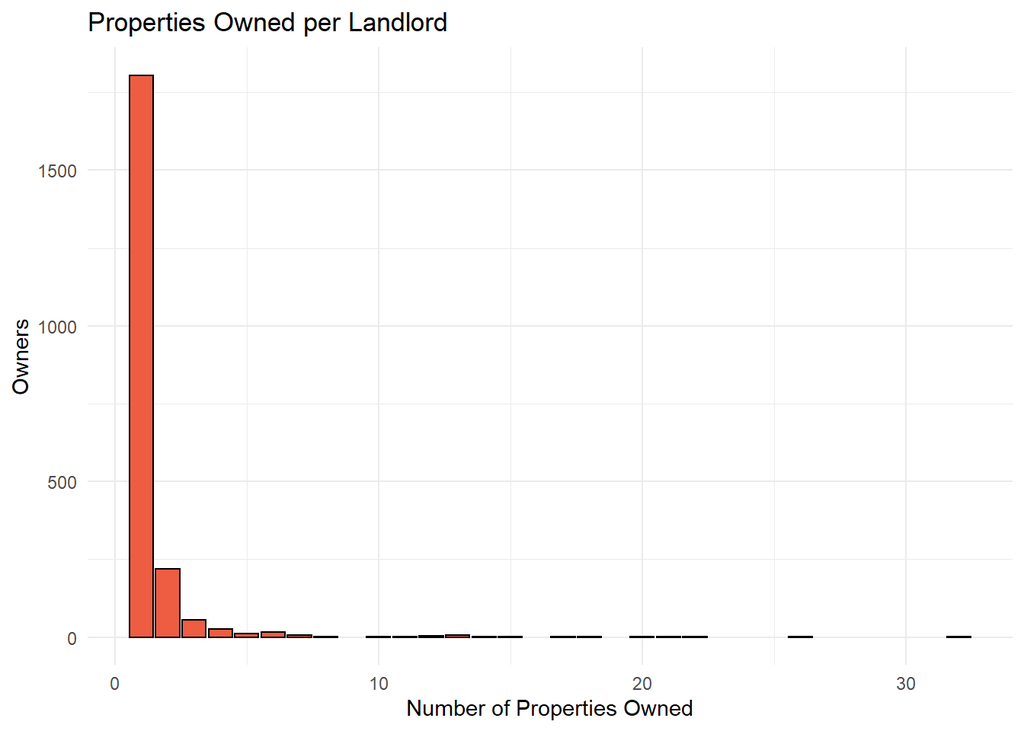

```r
ggplot(data = NumProperties,
       mapping = aes(nProperties)) +
        geom_bar(color = "black",fill="tomato2")+
        labs(title = "Properties Owned per Landlord",x="Number of Properties Owned",
             y = "Owners")+
        theme_minimal()
```

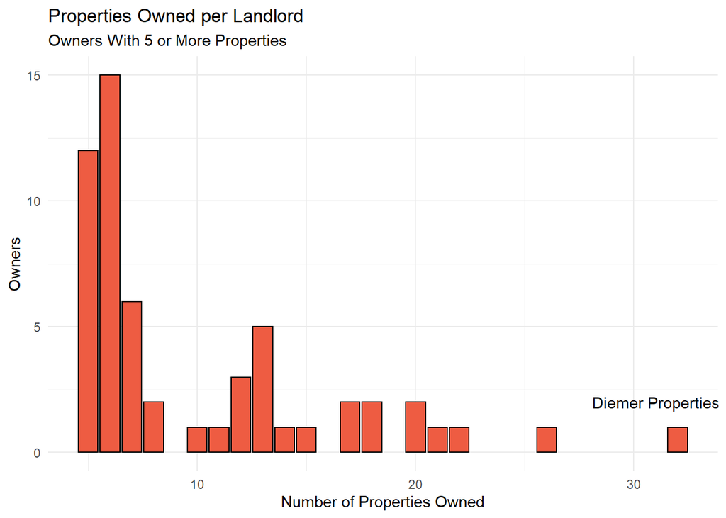

```r
ggplot(data = NumProperties %>% filter(nProperties >= 5),mapping = aes(nProperties)) +
        geom_bar(color = "black",fill="tomato2")+
        labs(title = "Properties Owned per Landlord",x="Number of Properties Owned",
             y = "Owners",subtitle = "Owners With 5 or More Properties")+
         annotate( geom = 'text', x = 31, y = 2, label = "Diemer Properties")+
        theme_minimal()
```

## Graph 2: Top 20 Landlords in Burlington

To give some context and greater detail on the landlords in Burlington, here are the top 20 landlords, their total properties owned, and the total value of those combined properties. There are a few interesting outliers in terms of total value – notably, Claire Pointe Owners Association controls 18 properties, but, combined, the properties it does own are 6 times the value of all the Diemer Properties properties combined, even though Diemer properties owns almost twice as many properties.

```r
library(knitr)

kable(properties %>%
  group_by(Owner) %>%
  summarize(
    NumberOfProperties = n(),
    TotalValue = sum(PropertyValue)
  ) %>%
  arrange(desc(NumberOfProperties)) %>%
  head(20, NumberOfProperties), caption="Top 20 Landlords in Burlington by Number of Properties Owned")
```

Top 20 Landlords in Burlington by Number of Properties Owned

| Owner | NumberOfProperties | TotalValue |
| --- | --- | --- |
| DIEMER PROPERTIES | 32 | 5695800 |
| MCGOWAN JOHN STUART | 26 | 8411300 |
| CHAMPLAIN HOUSING TRUST INC | 22 | 6491200 |
| BPJS MANAGEMENT LLC | 21 | 8839200 |
| J & S LLC | 20 | 9104400 |
| ROONEY RICHARD A | 20 | 3280900 |
| CLAIRE POINTE OWNERS ASSOCIATION | 18 | 33130800 |
| PBGC LLC | 18 | 9997500 |
| BURLINGTON REALTY ASSOCIATES | 17 | 2463700 |
| SISTERS & BROTHERS INVESTMENT GROUP LLP | 17 | 13985100 |
| LARKIN JOHN INC | 15 | 3132900 |
| OFFENHARTZ INC | 14 | 6359300 |
| BOYDEN DOUGLAS G | 13 | 5318800 |
| BURLINGTON HOUSING AUTHORITY | 13 | 22981220 |
| PHE INC | 13 | 2634700 |
| RIELEY PROPERTIES LLC | 13 | 7468500 |
| SWB LLC | 13 | 5180000 |
| KHAMNEI CHRIS C | 12 | 5832500 |
| LAFAYETTE MELISSA B | 12 | 3812600 |
| UNIVERSITY OF VERMONT MEDICAL CENTER INC | 12 | 3248000 |

## Graph 3: Types of Rental Properites

There are 15 active land use codes in our data set for the rental properties in Burlington. The most common is a two family rental, with one to 5 family apartments, and residential condos taking up the very large majority of properties. The commerical/residential properties (residential above commercial properties e.g. Church Street) are the next most common.

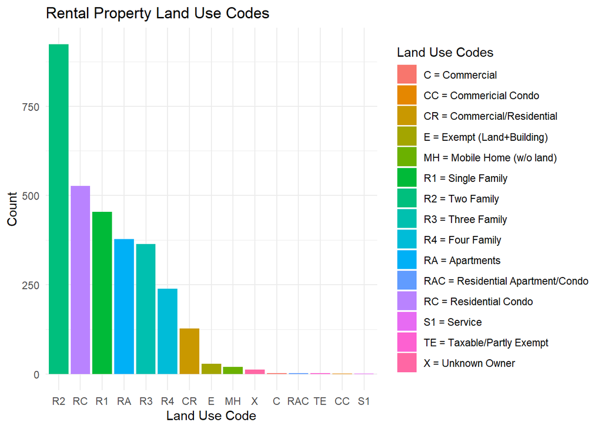

```r
propertiesOrdered <- properties %>% group_by(LandUseCode)%>%
  mutate(ncodes = n()) %>% filter(!is.na(LandUseCode))

ggplot(data = propertiesOrdered,
       mapping = aes(x = reorder(LandUseCode, desc(ncodes)), fill = LandUseCode)) +
        geom_bar()+
        labs(title = "Rental Property Land Use Codes",
             x = "Land Use Code",
             y = "Count",
             fill = "Land Use Codes")+
        theme_minimal()+
        scale_fill_discrete(labels = c("C = Commercial","CC = Commericial Condo",
                                       "CR = Commercial/Residential","E = Exempt (Land+Building)","MH = Mobile Home (w/o land)",
                                       "R1 = Single Family","R2 = Two Family","R3 = Three Family","R4 = Four Family","RA = Apartments",
                                       "RAC = Residential Apartment/Condo","RC = Residential Condo","S1 = Service","TE = Taxable/Partly Exempt",
                                       "X = Unknown Owner"))
```

## Graph 4: Certificate of Compliance

The Certificate of Compliance (CoC) is a certificate issued by the city of Burlington to certify that a property is in compliance with local codes and ordinances. The number of years a CoC is valid for is determined by how consistently the property has complied with Burlington’s property codes. If the property has complied with the code very consistently, they will be issued a Certificate of Compliance that is good for 5 years (the max). The majority of properties have 4 or 5-year certificates. Properties with a 0-year certificate either failed inspections in the most recent inspection or have not been inspected due to COVID-19.

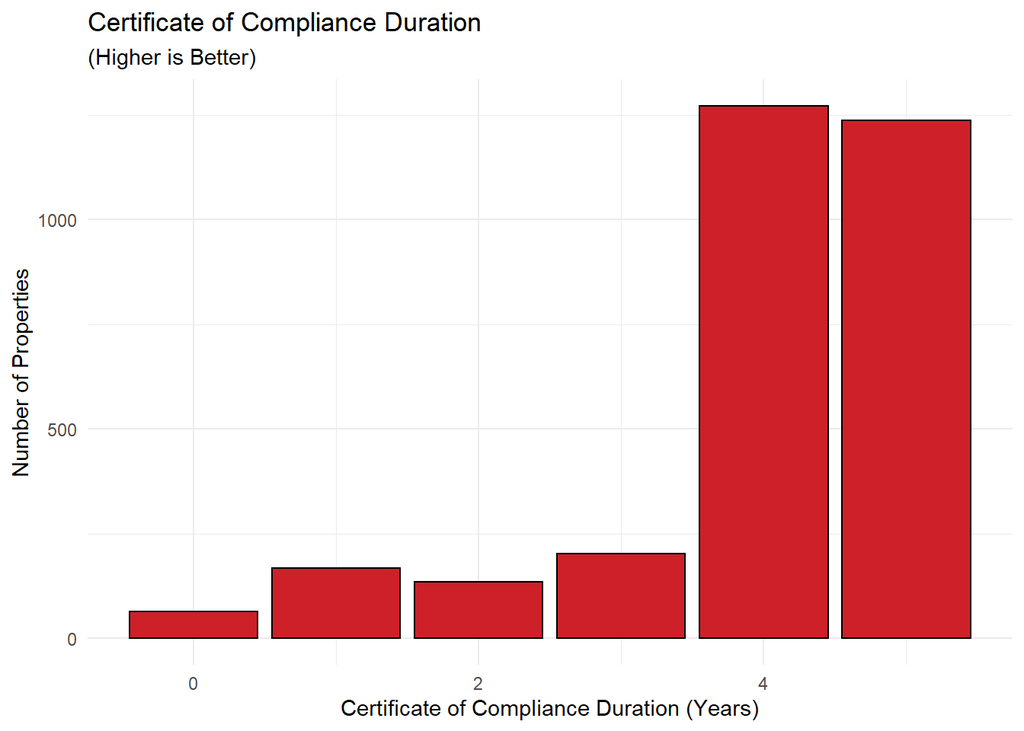

```r
ggplot(data = properties %>% filter(!is.na(CoCYears)), mapping = aes(x=CoCYears)) +
        geom_bar(color = "black",fill = "#CE2029")+
        labs(title = "Certificate of Compliance Duration",
             subtitle = "(Higher is Better)",
             x="Certificate of Compliance Duration (Years)",
             y = "Number of Properties")+
        theme_minimal()
```

## Graph 5: Does CoC Affect Property Value

The original hypothesis was that the properties with a less desirable CoC would have a lower property value. However, from the boxplots below we learned that the property value across all year values for the CoC was very similar. The median property value for all CoC years was ~$275,000.

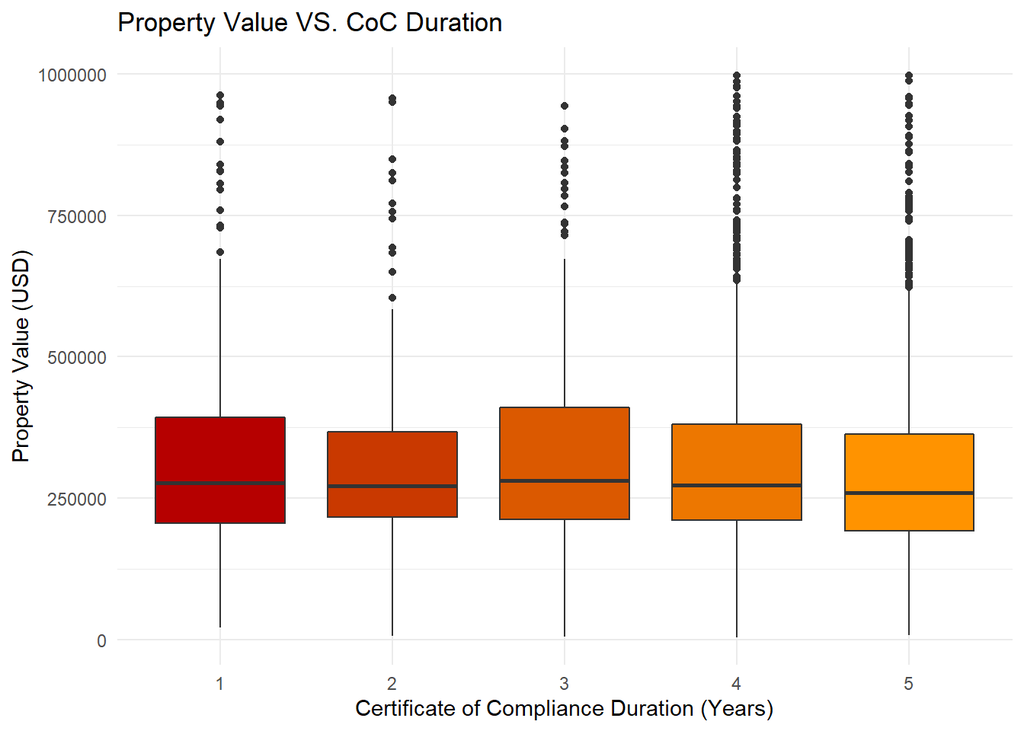

```r
ggplot(data = properties %>%
               filter(!is.na(CoCYears) & CoCYears != 0 & !is.na(LastMhInspectionDate) & PropertyValue < 1000000),
       mapping = aes(x=factor(CoCYears), y=PropertyValue,fill = CoCYears)) +
        geom_boxplot()+
        labs(title = "Property Value VS. CoC Duration",
             x = "Certificate of Compliance Duration (Years)",
             y = "Property Value (USD)")+
        scale_fill_gradient(high = "#ff9300",low = "#b60000")+
        guides(fill=FALSE)+
        theme_minimal()
```

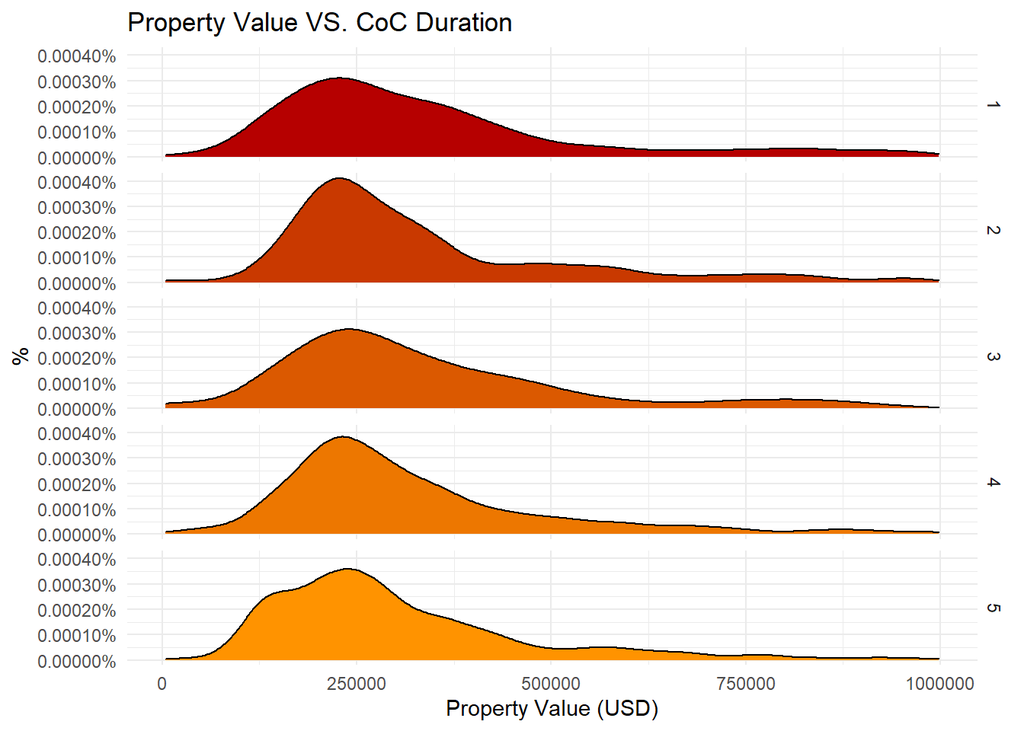

```r
#scale_fill_gradient(high = "#ff9300",low = "#b60000")+

ggplot(data = properties %>%
               filter(!is.na(CoCYears) & CoCYears != 0 & !is.na(LastMhInspectionDate) & PropertyValue < 1000000),
       mapping = aes(x= PropertyValue,fill = CoCYears))+
  geom_density()+
  scale_y_continuous(name = "%", labels=scales::percent)+
  scale_fill_gradient(high = "#ff9300",low = "#b60000")+
  facet_grid(CoCYears ~ .)+
  labs(title = "Property Value VS. CoC Duration",
             y = "Certificate of Compliance Duration (Years)",
             x = "Property Value (USD)")+
        guides(fill=FALSE)+
        theme_minimal()
```

## Graph 6: Map of CoC Years for all properties in Burlington

The vast concentration of rental properties clearly lies in the Old North End neighborhood, and the areas surrounding UVM and downtown Burlington. The South End and New North End neighborhoods have a far lower density of rentals properties.

[figure not shown]

```r
ggmap::register_google(key = "AIzaSyBoXvBVphUedpDsc05jtjZbH5pQGZJWQLc")
ggmap(get_googlemap(center = c(lon = -73.225, lat = 44.485),
                    zoom = 13, scale = 2,
                    maptype ='terrain',
                    color = 'color',
                    alpha = 0.25)) +
  geom_point(aes(x = long, y = lat,
                 color = CoCYears), data = properties, size = 0.5) +
  theme(legend.position="right") +
  labs(title = "CoC Years of Properties", x = "Longitude", y = "Latitude")
```

# III. Machine Learning

### Create training and test set, compare proportions

```r
# Select only useful numeric columns & LandUseCode predictor. Filter out LandUseCodes which aren't seen often.
# Interesting thing to note -- adding lat and long increases the accuracy by a few percentage points -- probably because similar types of residences are often grouped together in neighborhoods.

properties_simple <- properties %>% select(LandUseCode, PropertyValue, PropertyTaxes, CoCYears, ResidentialUnits, RentalUnits, lat, long) %>% filter(!(LandUseCode %in% c("E", "MH", "X", "C", "CC", "RAC", "S1", "TE")))

RNGversion('3.5.3')
set.seed(1112)
sample <- sample(1:nrow(properties_simple), 1500)
RNGversion(getRversion())

train <- properties_simple[sample, ]
test <- properties_simple[-sample,]

prop.table(table(train$LandUseCode))
```

```
##
##        CR        R1        R2        R3        R4        RA        RC
## 0.0440000 0.1460000 0.3000000 0.1233333 0.0800000 0.1373333 0.1693333
```

```r
prop.table(table(test$LandUseCode))
```

```
##
##         CR         R1         R2         R3         R4         RA         RC
## 0.04037062 0.15552614 0.31369954 0.11846459 0.07809398 0.11383190 0.18001324
```

### Run C5.0 model on data

```r
model <- C5.0(x = train[,2:8],
              y = as.factor(train$LandUseCode))

# display simple facts about the tree

model
```

```
##
## Call:
## C5.0.default(x = train[, 2:8], y = as.factor(train$LandUseCode))
##
## Classification Tree
## Number of samples: 1500
## Number of predictors: 7
##
## Tree size: 27
##
## Non-standard options: attempt to group attributes
```

```r
# display detailed information about the tree

summary(model)
```

```
##
## Call:
## C5.0.default(x = train[, 2:8], y = as.factor(train$LandUseCode))
##
##
## C5.0 [Release 2.07 GPL Edition]      Tue May 04 12:45:30 2021
## -------------------------------
##
## Class specified by attribute `outcome'
##
## Read 1500 cases (8 attributes) from undefined.data
##
## Decision tree:
##
## ResidentialUnits > 2:
## :...ResidentialUnits <= 3:
## :   :...RentalUnits <= 1: R2 (3/1)
## :   :   RentalUnits > 1: R3 (194/15)
## :   ResidentialUnits > 3:
## :   :...RentalUnits <= 4: R4 (137/20)
## :       RentalUnits > 4: RA (209/17)
## ResidentialUnits <= 2:
## :...ResidentialUnits > 1:
##     :...PropertyTaxes <= 13260.92: R2 (474/31)
##     :   PropertyTaxes > 13260.92:
##     :   :...lat <= 44.47394:
##     :       :...CoCYears <= 4: R3 (2)
##     :       :   CoCYears > 4: R2 (3/1)
##     :       lat > 44.47394:
##     :       :...RentalUnits <= 1: R1 (5/2)
##     :           RentalUnits > 1: CR (7/1)
##     ResidentialUnits <= 1:
##     :...PropertyValue <= 163100:
##         :...long > -73.2167: RC (130/1)
##         :   long <= -73.2167:
##         :   :...lat <= 44.4706: RC (13)
##         :       lat > 44.4706:
##         :       :...long <= -73.2488: RC (5)
##         :           long > -73.2488:
##         :           :...PropertyValue <= 137400: RC (7)
```

[output cut: 45 more lines]

```
##       1    20     6     1               226    (g): class RC
##
##
##  Attribute usage:
##
##  100.00% ResidentialUnits
##   57.27% RentalUnits
##   37.00% PropertyTaxes
##   31.07% PropertyValue
##   29.87% long
##   21.80% lat
##    0.33% CoCYears
##
##
## Time: 0.0 secs
```

```r
pred <- predict(model,  test)

# cross tabulation of predicted versus actual classes
#  dnn = names given to dimensions of table, rows then cols

CrossTable(test$LandUseCode, pred,
           prop.chisq = FALSE, prop.c =FALSE,
           prop.r = FALSE,
           dnn = c('actual data', 'predicted data'))
```

```
##
##
##    Cell Contents
## |-------------------------|
## |                       N |
## |         N / Table Total |
## |-------------------------|
##
##
## Total Observations in Table:  1511
##
##
##              | predicted data
##  actual data |        CR |        R1 |        R2 |        R3 |        R4 |        RA |        RC | Row Total |
## -------------|-----------|-----------|-----------|-----------|-----------|-----------|-----------|-----------|
##           CR |         6 |        10 |        11 |         6 |        12 |        12 |         4 |        61 |
##              |     0.004 |     0.007 |     0.007 |     0.004 |     0.008 |     0.008 |     0.003 |           |
## -------------|-----------|-----------|-----------|-----------|-----------|-----------|-----------|-----------|
##           R1 |         3 |       191 |        14 |         2 |         1 |         4 |        20 |       235 |
##              |     0.002 |     0.126 |     0.009 |     0.001 |     0.001 |     0.003 |     0.013 |           |
## -------------|-----------|-----------|-----------|-----------|-----------|-----------|-----------|-----------|
##           R2 |         4 |        10 |       454 |         4 |         0 |         1 |         1 |       474 |
##              |     0.003 |     0.007 |     0.300 |     0.003 |     0.000 |     0.001 |     0.001 |           |
## -------------|-----------|-----------|-----------|-----------|-----------|-----------|-----------|-----------|
##           R3 |         1 |         0 |         3 |       168 |         4 |         1 |         2 |       179 |
##              |     0.001 |     0.000 |     0.002 |     0.111 |     0.003 |     0.001 |     0.001 |           |
## -------------|-----------|-----------|-----------|-----------|-----------|-----------|-----------|-----------|
##           R4 |         1 |         0 |         0 |         1 |       116 |         0 |         0 |       118 |
##              |     0.001 |     0.000 |     0.000 |     0.001 |     0.077 |     0.000 |     0.000 |           |
## -------------|-----------|-----------|-----------|-----------|-----------|-----------|-----------|-----------|
##           RA |         2 |         0 |         1 |         1 |         7 |       161 |         0 |       172 |
##              |     0.001 |     0.000 |     0.001 |     0.001 |     0.005 |     0.107 |     0.000 |           |
## -------------|-----------|-----------|-----------|-----------|-----------|-----------|-----------|-----------|
##           RC |         0 |        32 |         6 |         0 |         1 |         0 |       233 |       272 |
##              |     0.000 |     0.021 |     0.004 |     0.000 |     0.001 |     0.000 |     0.154 |           |
## -------------|-----------|-----------|-----------|-----------|-----------|-----------|-----------|-----------|
## Column Total |        17 |       243 |       489 |       182 |       141 |       179 |       260 |      1511 |
## -------------|-----------|-----------|-----------|-----------|-----------|-----------|-----------|-----------|
##
##
```